Course project 1INF52 Deep Learning 2026-2 · PUCP · report

# STRIDE: Smarter Tracking via Refined Image prompts for Daily-life Embodiment

SAM 3D Body stays frozen. We measure where it fails on daily-life video with a motion-capture ground truth, correct it with a small network that rewrites its key-point prompts, compare that with simpler corrections, and follow every motion to a Unitree G1 humanoid, kinematically and in physics simulation.

Adhemir Rodrigo Carbajal Satalaya, Alexander Franz Vasquez Montero  
Pontificia Universidad Católica del Perú · 11 November 2026

Contents

Abstract

1. Introduction
2. Terms and metrics
3. Data
4. SAM 3D Body and where it fails
5. Method: the prompt corrector
6. Main results
7. Where the gain comes from
8. From video to the robot
9. Failure cases and limitations
10. Conclusion and future work

Appendix A: ablations · Appendix B: reproducing · Appendix C: use of AI · References

## Abstract

Humanoid robots can learn whole-body skills from human motion recorded in everyday video, but single-image 3D body estimators are unreliable on such video. We evaluate SAM 3D Body on NymeriaPlus, daily-life video with a motion-capture ground truth, and propose a prompt corrector: a small network (2.5 M parameters) that keeps SAM 3D Body frozen and predicts the 2D joint positions the model accepts as hints (prompts). On 344 test clips of 6 unseen people, the corrector followed by temporal smoothing reduces the mean joint error from 84.2 to 66.7 mm (−21 %) and the frame-to-frame shaking almost fivefold. A network that corrects the 3D output without seeing the image reaches a similar error (68.7 mm), indicating that most of the gain corrects a systematic bias of the base model. Transferred to a Unitree G1 humanoid, the gain in joint angles is small (16.7° to 16.0°), and in physics simulation, imitation policies trained on either model's motion converge to similar behaviour.

**Keywords:** human mesh recovery, promptable models, occlusion, motion capture, humanoid imitation, domain shift.

## 1. Introduction

### 1.1 Motivation

Imitation learning lets a humanoid robot acquire whole-body skills from human demonstrations, and its bottleneck is data: motion-capture suits and studios are expensive, so the number of demonstrations stays small. Video is the obvious alternative. There are two kinds: cameras installed in a laboratory, with a controlled view of the person, and videos of daily routines, with a moving camera, partial views and occlusion. This project works on the second kind, because it is the one that can scale.

[figure not shown]

Figure 1. The two kinds of video. (a) A laboratory: the CMU Panoptic Studio, a dome whose walls hold hundreds of synchronized cameras (the black dots), which reconstructs the 3D pose of everyone inside [10, 11]; images from the dataset's website. (b) Daily life: frames of our NymeriaPlus test clips [8], filmed by a second person wearing camera glasses: the camera moves, the person can be far away, and tables, furniture or other people cover parts of the body.

To use such video we need the trajectory of every joint of the body in 3D. Modern single-image models predict the whole body from one picture, but video adds two problems that a single image does not show: the prediction changes from one frame to the next even when the person barely moves, and joints that are hidden (by the body itself, by furniture or by another person) have to be guessed.

### 1.2 Research question

Can SAM 3D Body, a single-image model, be trusted on everyday video as a source of motion for a humanoid, and what does it take to correct it where it fails? Concretely: which joint trajectories are wrong and why, how much a small learned module can fix without retraining the base model, where that fix comes from, and what of it reaches the robot.

### 1.3 Approach and contributions

- **A diagnosis** of SAM 3D Body (where its 3D joints are wrong, by how much and why) on 4428 daily-life clips of 127 people with a motion-capture ground truth: per joint, over time, under occlusion, and against its own benchmark.
- **The prompt corrector**: a small network (2.5 M parameters) that rewrites the 12 joint positions SAM 3D Body accepts as hints (its *prompts*), without changing the model. It is trained first to place the hints on the true joints in the image, then to make the model output the best 3D body.
- **An analysis of where the gain comes from**, with two simpler corrections as baselines: a fixed offset of the prompts and a network that corrects the 3D output without the image.
- **The path to a humanoid**: transferring the motion to a Unitree G1 robot on 35 clips (*retargeting*), and training a controller to imitate one clip in the MuJoCo physics simulator.

### 1.4 Relation to the course project

The course asks for three phases. The dissection of the base model (Phase A) is Section 4.2. The intervention in the model's core and its controlled ablations (Phase B) are Section 5 and Appendix A. The evaluation under a distribution shift with an analysis of failures (Phase C) is Sections 4.6 and 9: NymeriaPlus is not among the data SAM 3D Body was trained on, and it adds a fisheye camera that moves, distant people and occlusion.

## 2. Terms and metrics

The body model of this project is MHR (Momentum Human Rig), the skeleton SAM 3D Body predicts and in which NymeriaPlus gives its ground truth. Errors are measured over 18 body joints of MHR (pelvis, hips, knees, ankles, balls of the feet, spine, neck, head, shoulders, elbows, wrists), in the camera frame, averaged over frames with the whole body in view.

[figure not shown]

Figure 2. The MHR body model [12] on one frame of our data. (a) The ground-truth joints from the motion-capture suit, projected on the image. (b) The same body in 3D seen from the front: grey dots are the 127 joints of MHR (including fingers and face); the 18 coloured joints are the ones every error in this report is measured on, and the 12 orange ones are also the joints whose image position SAM 3D Body accepts as prompts (Section 2.3). MHR names some joints by the bone that starts there; here they are given their anatomical names.

### 2.1 Pose metrics

**MPJPE (mm)**

Mean per-joint position error after moving the predicted pelvis onto the true pelvis. It measures the *pose* of the body, not where the body is. The main metric of the report.

**PA-MPJPE (mm)**

The same after the best rotation, scale and translation (Procrustes alignment): only the shape of the pose, regardless of its orientation and size.

**Acceleration error (mm/frame²)**

Mean difference between the predicted and the true acceleration of each joint. It measures *jitter*, the shaking of the joints from frame to frame: a model that shakes from frame to frame has a high value even if its average position is right.

**Pelvis error (mm)**

Distance between the predicted and the true pelvis in the camera frame. It measures where the body is placed in the scene, mostly its depth.

**2D error (px)**

Distance in the image between a predicted key point and the true one, on 1024 × 1024 frames.

### 2.2 Robot metrics

Every motion is retargeted to the Unitree G1 and compared with the ground truth retargeted the same way.

**Joint angle error (°)**

Mean absolute difference of the robot's 29 joint angles against the ground-truth robot.

**Joint jitter (°/frame²)**

Mean absolute second difference of the joint angles: how much the robot's joints shake.

**Base trajectory error (cm)**

Distance between the displacement of the robot's pelvis from the first frame and that of the ground-truth robot.

**Foot sliding (cm/s)**

Horizontal speed of the robot's feet in the frames where the ground-truth robot's foot is planted. Real walking gives about 5 cm/s.

### 2.3 Names of the models

**Prompt**

A hint given to SAM 3D Body: the 2D position in the image of one of its joints. The model was built so that a person can click such points to fix its output; it then adjusts the whole body to them.

**SAM 3D Body**

The base model, frozen, frame by frame, with the person's box and the camera given.

**SG**

Savitzky-Golay filter: a standard smoothing filter that fits a low-order polynomial to each joint's trajectory over a short window (9 frames, order 2). It removes the frame-to-frame shaking.

**Oracle prompts**

SAM 3D Body given the true image positions of 12 joints as prompts, taken from the motion-capture ground truth. It is not usable in practice (the truth is unknown at test time); it tells how good the output can get if the prompts are perfect.

**Prompt corrector**

Our network that predicts better prompts (Section 5). *2D-trained* is its first training stage alone; *with body context* is a variant that also reads SAM 3D Body's predicted body over ±2 s around the frame.

**Final pipeline**

Prompt corrector + SG.

**Fixed prompt offset**

A baseline without a network: the mean training offset of each key point added to SAM 3D Body's points.

**Image-free 3D correction**

A baseline network that corrects SAM 3D Body's 3D joints from its own predicted body over ±16 frames, without the image.

### 2.4 All models and experiments at a glance

Every model, baseline and ablation of the report in one place: what changes, which question it answers, its main result (pose error MPJPE on the 344 test clips unless noted) and where it is introduced (first) and analysed in detail (second).

Table 1. Models and experiments of the report.

| name | what changes | question it answers | main result | introduced · detailed |
| --- | --- | --- | --- | --- |
| Base model and reference points |  |  |  |  |
| SAM 3D Body | the frozen base model, frame by frame | the starting point | 84.2 mm; pelvis 220 mm | §4.1 · §4.3, §6.2 |
| SAM 3D Body + SG | + Savitzky-Golay smoothing of the joints | does smoothing fix the error? | 83.4 mm; jitter 17.2 → 3.6 | §4.4 · §6.2 |
| Oracle prompts | the true image positions of 12 joints as prompts | how much can better prompts give? | 61.4 mm (not usable at test time) | §4.5 · §6.2 |
| Our method |  |  |  |  |
| Prompt corrector | our network after both training stages: stage 1 puts the 12 points on the true 2D joints; stage 2 trains it through the frozen decoder on the 3D body error | — | 67.6 mm | §5 · §6.2 |
| Final pipeline | prompt corrector + SG | — | 66.7 mm; jitter 3.7 | §5 · §6, §8 |
| Prompt corrector, 2D-trained | the same network after stage 1 only: it learned to move the points onto the true 2D joints, never trained on the 3D body | does training through the decoder (stage 2) help? | 73.4 mm; pelvis 137 mm | §5.4 · §6.3, A.2 |
| Corrector with body context | the prompt corrector with one more input, SAM 3D Body's predicted body in the 2 s before and after the frame (one token per frame), and a loss term that keeps the body where it is in the image | does seeing the motion around the frame help the pose or the position? | 67.8 mm; pelvis 150 mm | §5.2 · §6.3, A.11 |
| Simpler corrections (baselines) |  |  |  |  |
| Fixed prompt offset | a constant shift of each prompt, no network | is the gain a constant skeleton difference? | 80.6 mm | §7 |
| Image-free 3D correction | network on the predicted body over ±16 frames; no image, no prompts | does the corrector read the image? | 68.7 mm | §7 |
| … + pelvis term / own box | also moves the pelvis / box from its own joints | position; dependence on the true box | 68.7 mm, pelvis 162 / 70.5 mm | §7 |
| Ablations (Appendix A; some on the earlier 223-clip test set) |  |  |  |  |
| Hand decoders | full mode with the hand decoders | do they improve the wrists? | no change, 3× slower | A.1 |
| 2D vs 3D objective | stage 1 only vs stage 1 + 2 | which objective is better? | 3D: better pose, worse pelvis | A.2 |
| Position term + context ±0.5 s | reprojection loss + body over ±16 frames | keep the body in place? | pelvis recovered, +0.7 mm pose | A.3 |
| Filter after the corrector | SG on the corrector's output | remove the added jitter? | jitter −80 %, pose kept | A.4 |
| More frames, same people | +58 % training frames | does more data of the same people help? | −1.3 mm | A.5 |
| More people | +50 people, +10 % samples | does variety of people help? | −1.6 mm | A.6 |
| Longer window ±2 s, masked | body context over ±60 frames | recover long occlusions? | no gain on occlusion | A.7 |
| Forced occlusion | hide body parts during training | learn to infer hidden parts? | no gain, discarded | A.8 |
| Latent storage | compression of the stored image features | how much compression is safe? | 8-bit per channel, 0.10 mm | A.9 |
| Pretrained motion prior | MDM + noise optimisation to fill hidden joints | can a motion prior fill a hidden leg? | worse than the base model | A.10 |
| From video to the robot |  |  |  |  |
| Retargeting to the G1 | each motion → Unitree G1 joint angles (GMR), 35 clips | does the gain reach the robot? | angles 16.7° → 16.0°; feet slide more | §8.1–8.2 |
| Physics imitation | one policy per reference, MuJoCo, one clip | what does physics do with the references? | policies keep a foot down, end alike | §8.3 |

## 3. Data

### 3.1 NymeriaPlus and what we use from it

Each sequence of Nymeria has video from several Aria glasses (the participant's head and wrists, and an observer who films the participant from a third-person view), audio, narrations written by annotators about every 5 seconds, and the participant's body motion from an XSens suit (inertial sensors on every body segment), 240 times per second, in world coordinates. NymeriaPlus fits that motion to MHR. We use the observer's video as the input, as a stand-in for a third-person camera, and the MHR motion as the ground truth. To compare them we use three more parts of the dataset: the clock synchronisation between the suit and the observer's glasses, the SLAM trajectory of the observer's glasses (the camera moves with the person who films), and the camera calibration.

[figure not shown]

Figure 3. How Nymeria records one sequence, shown on the same scene in every panel (figures from the Nymeria project page [8]). The grey point cloud is the room reconstructed by the glasses' SLAM; the green line is the trajectory of the participant's head, the blue and cyan lines those of the wrists, and the red line the gaze. (a) The participant's Aria glasses (head camera, eye tracking). (b) Aria wristbands on both wrists. (c) The XSens suit gives the body's skeleton at 240 Hz. (d) The observer, a second person wearing Aria glasses (small camera icon on the right), films the participant from a third-person view; the bottom-left inset is that video. (e) NymeriaPlus fits the suit's motion to the MHR body. We use (d) as the input and (e) as the ground truth; the clocks of all devices are synchronised, and the observer's SLAM trajectory gives the camera's position at every frame.

### 3.2 Camera and ground truth in the image

The observer records with a fisheye lens, which SAM 3D Body does not expect. We rectify every frame to a 1024 × 1024 pinhole camera with a focal length of 450 px (about 97° field of view), upright, and give the model the exact intrinsics. For every frame, the ground-truth pose is the body frame nearest in time (measured offset below 2.6 ms), moved from the world into the camera with the observer's pose at that instant, and projected with the same intrinsics. On a clip used for the qualitative analysis, shifting the ground truth in time by up to ±2 s against the image evidence gives its best agreement at a shift of 0 frames.

### 3.3 Selecting the motions

Watching 340 hours of video is not possible, and each video weighs about 16 GB, so the motions are selected from the narrations before any video is downloaded. A narration is a short text with its start and end time, written about every 5 seconds. We kept the motions relevant for a humanoid (sports, dance, exercise, walking, jumping, daily actions) and labelled each narration by the movement the body makes, because the same word covers very different movements ("hit" can be a badminton stroke, a table-tennis stroke or a punch). For dance, badminton, table tennis and soccer the label goes one level deeper: the footwork of a dance, the type of stroke, how a ball is kicked. On 19 sequences the 2465 narrations were labelled by hand (79 actions in 11 categories); on the remaining 185 sequences the labels were assigned by keyword rules written from those hand labels, keeping a fine action only where the rules were precise enough and the category otherwise. The automatic category agrees with the hand labels on 85.6 % of the hand-labelled narrations, an optimistic figure since the rules were written from them; the automatic labels were not checked by hand.

[figure not shown]

Figure 4. From a narration to a training clip, with a real narration of a badminton sequence. Only the seconds that satisfy every criterion of step 3 become a clip; each clip keeps its frames and its ground truth.

### 3.4 Cutting clips

A clip is a run of consecutive seconds with the same label, the whole body in the image in every second, a mean limb speed of at least 0.3 m/s and a length of 3–30 s; sitting and idle time are left out. This gives **4428 clips, 628.7 min, 127 people, 11 categories**. Each clip is extracted as rectified frames at 30 fps with its ground truth.

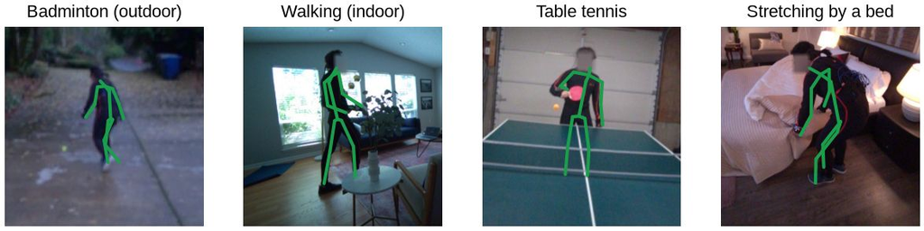

Figure 5. Four test clips with the ground-truth skeleton (green) projected on the rectified image: outdoor and indoor scenes, small and large people, a table and a bed in front of the body.

### 3.5 Split by person

Table 2. Split by person over the 127 people.

| split | people | clips | minutes | frames |
| --- | --- | --- | --- | --- |
| train | 115 | 3577 | 507.1 | 912 780 |
| validation | 6 | 507 | 63.8 | 114 840 |
| test | 6 | 344 | 57.7 | 103 920 |

All results in Sections 6–7 are on the 344 test clips (103 890 frames with the whole body in view). Some ablations in Appendix A were run earlier on 223 of them (the test set before it was extended with 121 clips of the same 6 people); they say so.

## 4. SAM 3D Body and where it fails

### 4.1 SAM 3D Body

SAM 3D Body takes a crop of the person, encodes it with a DINOv3-H+ vision transformer into a 32 × 32 grid of tokens of 1280 channels (the *latent*: everything the model extracted from the image), and decodes the body with a promptable Transformer decoder that predicts the MHR pose, shape and camera. The decoder can take prompts: 2D positions of any of its 70 key points, or a mask. We use the released DINOv3-H+ checkpoint, frozen, in body mode (without the hand decoders, Appendix A.1), with the box of the person given and the camera intrinsics known.

[figure not shown]

Figure 6. SAM 3D Body (diagram from its official repository [9]). The encoder turns the crop of the person into image features. The body decoder reads them through cross-attention, together with query tokens (the MHR token, the camera token and the prompt tokens: 2D key points the user can give), and outputs the pose, shape, skeleton and camera of the MHR body. The hand decoder refines the hands from hand crops; we do not use it (Appendix A.1). Our method acts only on the keypoint prompts.

### 4.2 Dissection of the model

Table 3. Where SAM 3D Body spends its parameters, compute and time (one person, body mode).

| part | parameters | share of FLOPs | time |
| --- | --- | --- | --- |
| whole model | 1285 M (953 M learned) | 1938 GFLOPs | 144 ms per frame, 3.5 GB peak memory |
| image encoder (DINOv3-H+, 32 blocks) | 840.6 M | 98.1 % | 50 ms |
| body decoder (promptable) | 39.4 M | 1.7 % | 78 ms (calls the MHR head 6 times) |
| MHR body model | 173.5 M (7.4 M learned) | 0.1 % | within the decoder |

The encoder holds almost all the parameters and compute, while the decoder takes more time because it is iterative. This shape is what makes our intervention possible: the expensive part runs once per frame and its latent can be stored, and the cheap part can be run again many times with new prompts during training.

The figure below shows the effective receptive field of the encoder token at the position of several joints: the area of the image that holds half of the gradient of that token. For the visible right wrist it covers 2 % of the image around the wrist; for the occluded left wrist it covers 8.6 %, with most of its mass on the head and the torso. When a joint is hidden, the token at its position is built from the context of the body, so its prediction is inferred rather than observed. A principal-component view of the patch features shows region-level structure (person, floor, wall) without a clear separation of body parts at this resolution.

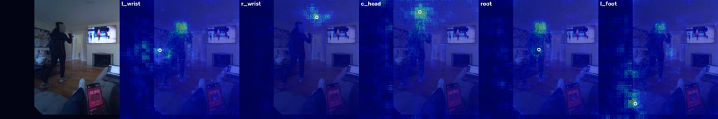

Figure 7. Effective receptive field of the encoder token at the image position of the left wrist (occluded), right wrist (visible), head, pelvis and left foot, on one frame of a dance clip. Brighter cells receive more of the gradient.

### 4.3 Baseline on daily-life video

On the 992 hand-labelled clips of 19 people (227 551 frames), SAM 3D Body reaches 85.0 mm MPJPE (57.2 mm PA-MPJPE), and its joints accelerate 4.5 times more than the real motion (26.4 against 5.9 mm/frame²): they shake. The error grows towards the ends of the limbs and changes little across kinds of motion.

[figure not shown]

Figure 8. SAM 3D Body on 992 clips of 19 people. (a) Mean error per joint, after aligning the pelvis (which is why the pelvis and hips are near zero): the feet and wrists are the worst (up to 133 mm), the trunk the best. (b) Mean error per category of motion: from 79.5 mm (exercise) to 100.4 mm (daily actions).

Two observations set the direction of the project. First, the error of an occluded joint is a sustained offset, not a spike: only 0.3 % of the joint positions jump by more than 10 cm from one frame to the next, and on the first dance clip the occluded left wrist stays near 211 mm while it is hidden. Second, a classical filter removes the shaking but not that offset (Section 4.4). Whatever we add has to fix sustained errors, not only smooth the trajectory.

### 4.4 Jitter can be filtered, sustained error cannot

Classical filters act on the output trajectories. On the 992 hand-labelled clips, Savitzky-Golay brings the jitter close to that of the real motion while MPJPE barely moves; One-Euro lags behind the motion. The error of an occluded joint is a sustained offset, not noise, so a model that corrects joints is needed, and a filter is kept only to remove jitter.

[figure not shown]

Figure 9. Classical filters on the 992 clips: Savitzky-Golay brings the jitter close to that of the real motion while the position error barely moves; One-Euro smooths but lags behind the motion.

### 4.5 The prompts are a strong lever

The decoder of SAM 3D Body accepts 2D key points as prompts (the keypoint prompts in Figure 6), designed for a person correcting it by hand. If we give it the 12 true key points (shoulders, elbows, wrists, hips, knees, ankles), its MPJPE on the 344 test clips falls from 84.2 to 61.4 mm (−27 %), better on every test person. Joints that receive no prompt improve too, because the decoder rearranges the whole body around the points. At test time there are no true key points: the question is how much of that gain a network can recover from what the model already computed.

Figure 10. MPJPE of SAM 3D Body, with the SG filter, and with the 12 true key points as prompts (oracle), on the 344 test clips. The filter changes the pose error by less than 1 mm; the true prompts lower it by 23 mm.

### 4.6 Domain shift

NymeriaPlus is not among the data SAM 3D Body was trained or evaluated on. It differs in the camera (a rectified fisheye that moves with the person who films), in the size of the person (10th to 90th percentile of the person's height: 110 to 397 px on the 1024 px image) and in the occlusion of daily life. The SAM 3D Body paper reports 54.8 mm MPJPE on 3DPW, a standard benchmark of outdoor video with motion capture; we measure 84.2 mm here. The two numbers are not strictly comparable: the paper converts its output to SMPL, another common body model, and measures 14 of its joints, we use 18 MHR joints, and 3DPW is part of SAM 3D Body's training data. We did not reproduce the 3DPW number on our setup.

Figure 11. SAM 3D Body on its own benchmark (number reported in its paper) and on our test set. Different joint sets; the gap is indicative, not a controlled measurement.

## 5. Method: the prompt corrector

### 5.1 Why correct the prompts

The oracle shows that the right 12 prompts remove most of the error, including that of joints without a prompt. Correcting the prompts acts inside the model while keeping it frozen: the final body still comes from SAM 3D Body's decoder and body model, so it stays a valid human body. The prompts must be given for all 12 points in every frame; prompts that appear and disappear between frames make the body jump.

### 5.2 Architecture

The figure below shows where the corrector sits inside SAM 3D Body (a) and what it is made of (b). For a frame t:

[figure not shown]

Figure 12. (a) Where the prompt corrector sits: SAM 3D Body runs once as usual (grey, frozen); its 12 predicted key points and the image features of three frames go into the corrector (blue, the only trained part), whose corrected points are given back to SAM 3D Body as prompts for a second pass that produces the final body. (b) Inside the corrector. The image features become a memory of 3072 tokens; SAM 3D Body's 12 points become 12 queries, one per joint. A two-layer Transformer decoder lets each joint look at the other joints (1), then at the image memory (2), then refines it alone (3). A last linear layer outputs, for each point, a 2D correction, which is added to SAM 3D Body's point to give the prompt (the 12 prompts of panel a), and an uncertainty used only in the training loss. The correction starts at zero, so before training the prompts are SAM 3D Body's own points. White blocks have no parameters.

- **Memory: what the model saw.** The encoder latent of frames t−1, t and t+1: 3 × 32 × 32 = 3072 tokens of 1280 channels, each projected to 256 channels by a 1 × 1 linear layer. Each token gets the position of its cell in the crop of frame t (16 Fourier frequencies, so a token of a neighbouring frame is placed where it falls in the current crop) and an embedding of which of the three frames it comes from.
- **Queries: where to start.** One query per key point. Its content is SAM 3D Body's own prediction of that point: its 2D position in the three frames (normalised to the crop of t) and its 3D position (15 numbers), passed through a small MLP together with Fourier features of the 2D position at t, plus a learned embedding of which joint it is.
- **Network.** A Transformer decoder with 2 layers, 8 heads, width 256 and feed-forward width 1024 (pre-normalisation, dropout 0.1). In each layer the 12 queries attend to each other (self-attention: the body is one structure, and a hidden knee can be placed from the hip and ankle) and to the latent tokens (cross-attention: where in the image the evidence for each joint is).
- **Output.** For each key point, a 2D correction (in crop units, scaled to pixels) and the logarithm of a scale b, the expected size of the error of that point. The output layer starts at zero, so before training the corrector returns SAM 3D Body's own points; with its own points as prompts the model changes by only +1.0 mm on the first clip, so training starts at the baseline.

The network has 2.54 M parameters, about 0.2 % of SAM 3D Body.

**Variant with body context.** To give the corrector the motion around the frame, a second version adds SAM 3D Body's whole predicted body (29 joints, 2D in the crop and 3D around the pelvis) for every frame of a longer window, one token per frame (an MLP of the 145 numbers plus a learned embedding of the time offset), to the memory. Frames that fall outside the clip are masked in the attention instead of repeating the end frame. We used windows of ±16 and ±60 frames (±0.5 and ±2 s). Its results are in Table 4 (Section 6.2) and Appendix A.11, and the ±16-frame version in Appendix A.3.

### 5.3 Why this design

- *Latent instead of the image.* The latent is what SAM 3D Body already understood of the image; reading it lets a small network work at the level of body parts instead of pixels, and costs no extra encoder pass.
- *The model's own points as queries.* They tell the network where to start, so it only has to learn a correction, which is a smaller and better-conditioned target than an absolute position.
- *Three frames.* The neighbouring frames show a joint that is hidden or blurred at t; three frames keep the stored latent per sample small.
- *An uncertainty per point.* It comes out of the same loss with no extra label, and it says how much to trust each correction.
- *A correction of the prompts, not of the output.* The final body still comes from SAM 3D Body's decoder and body model, so it stays a valid human body.

### 5.4 Training objectives

**Stage 1, in 2D.** The corrector is trained to bring its points to the true 2D key points with a Laplace likelihood, which learns the correction and its uncertainty together:

L<sub>2D</sub> = mean over points of [ ‖ Δ − Δ* ‖<sub>1</sub> / b + 2 log b ]

where Δ is the predicted correction, Δ* the correction that would reach the true point, and b the predicted scale.

**Stage 2, in 3D through the frozen decoder.** Starting from stage 1, every training step runs SAM 3D Body's decoder with the corrected points as prompts (from the stored first-pass state of the frame) and compares the final body with the ground truth: the pelvis-aligned error of 18 body joints, plus 0.1 × L<sub>2D</sub>. The gradient flows through the frozen decoder into the corrector, so it learns the points that produce the best body, not only the points closest in pixels.

**Variant with forced occlusion.** To teach the corrector to infer hidden parts, a training variant hides one body part in half of the samples: the latent tokens that fall inside the true 2D box of the lower body, one leg or one arm (plus 15 % margin) are replaced by one learned token in the three frames, and the joints of that part get noise (5 % of the crop in 2D, 5 cm in 3D) in the input points and in the body window. It is used only in training and is evaluated in Appendix A.8.

**Variant with body position.** The pelvis-aligned error does not see where the body is. The body-context variant adds the 2D reprojection error (in pixels, weight 1) of the 18 joints of the final body, so that the body stays where the person is in the image.

### 5.5 Implementation

- *Stored latent.* The encoder runs once per frame; its latent is stored as 8-bit integers with one scale per channel (1.31 MB per frame instead of 2.6 MB in 16-bit float, with a pose loss of 0.10 mm, Appendix A.9), together with the decoder's first-pass state. For most training clips it is stored only for t−1, t and t+1 around one frame every 30 frames, which keeps the 248 225 training samples within a 789 GB disk.
- *Optimisation.* AdamW with cosine decay. Stage 1: 5 epochs, batch 32, learning rate 1e-4, from scratch. Stage 2 and the body-context variant: 2 epochs, batch 16, learning rate 5e-5, starting from stage 1. The model kept is the epoch with the lowest validation MPJPE (stage 1: lowest validation 2D error). Seed 0.
- *Compute.* One RTX 4070 (12 GB). One epoch of stage 1 on the final data takes about 27 min; one epoch of stage 2 about 83 min, because every step runs the decoder with gradients (15 ms per frame at batch 16).

## 6. Main results

### 6.1 Protocol

Every model is chosen on the validation people (lowest validation MPJPE; lowest 2D error for the 2D-trained stage) and evaluated once on the 344 test clips of 6 people who appear neither in training nor in validation. Averages are weighted by frames.

### 6.2 Pose, smoothness and position

Table 4. Test results on the 344 clips (103 890 frames). Lower is better in every column.

| model | MPJPE | PA-MPJPE | accel. error | pelvis error |
| --- | --- | --- | --- | --- |
| SAM 3D Body | 84.2 | 55.1 | 17.2 | 220.1 |
| SAM 3D Body + SG | 83.4 | 54.7 | 3.6 | 219.2 |
| Prompt corrector, 2D-trained | 73.4 | 49.3 | 17.5 | 136.8 |
| Prompt corrector | 67.6 | 47.5 | 18.4 | 176.8 |
| Prompt corrector with body context (±2 s) | 67.8 | 47.7 | 18.5 | 149.5 |
| **Final pipeline: prompt corrector + SG** | **66.7** | **46.9** | 3.7 | 175.0 |
| Oracle prompts (upper bound) | 61.4 | 40.7 | 12.1 | 138.0 |

[figure not shown]

Figure 13. Left: pose error of every model on the 344 test clips, including the two baselines of Section 7 (orange). Right: jitter; the corrector alone adds jitter, which the SG filter removes.

The final pipeline lowers MPJPE by 17.5 mm (−21 %) and recovers 77 % of the oracle gain (22.8 mm), with the jitter of the filtered baseline. The corrector adds jitter on its own (17.2 → 18.4 mm/frame²), because each frame is corrected independently; the filter removes it at no cost in pose (Appendix A.4).

### 6.3 Per person and the position of the body

[figure not shown]

SAM 3D Body + SGPrompt corrector + SG (final)Oracle prompts

Figure 14. MPJPE per test person. The final pipeline improves every person, by 12 to 26 mm, and stays 2–7 mm above the oracle.

The 3D-trained corrector improves the pose most but not where the body is: its loss is aligned at the pelvis, so it does not see the body's position (pelvis error 176.8 mm against 136.8 mm for the 2D-trained stage). The body-context variant recovers most of the placement (149.5 mm) at the same pose error.

[figure not shown]

Figure 15. Pose error against position error on the 344 test clips (lower-left is better). Blue, the prompt correctors: *Prompt corrector* is the final model (trained first in 2D, then in 3D through the frozen decoder) and *+ SG (final)* the same followed by the smoothing filter; *2D-trained* is its first training stage alone, which places the body better but the pose worse (Appendix A.2); *with body context* also reads SAM 3D Body's predicted body over ±2 s and has a position term in its loss (Appendices A.3 and A.11). Orange: the two simpler corrections of Section 7 (fixed prompt offset; image-free correction with a pelvis term). Grey: SAM 3D Body. Green: the oracle prompts.

### 6.4 Occlusion by objects

On 30 test clips where a table, furniture or another person covers part of the participant (found by inspecting four frames of each clip), the corrector lowers MPJPE from 96.1 to 71.8 mm, slightly below the oracle (73.3 mm): the true 2D key points of a hidden leg are themselves a weak prompt. What it cannot do is shown below: a leg extended back behind the body is hidden in depth, and no 2D prompt can express depth.

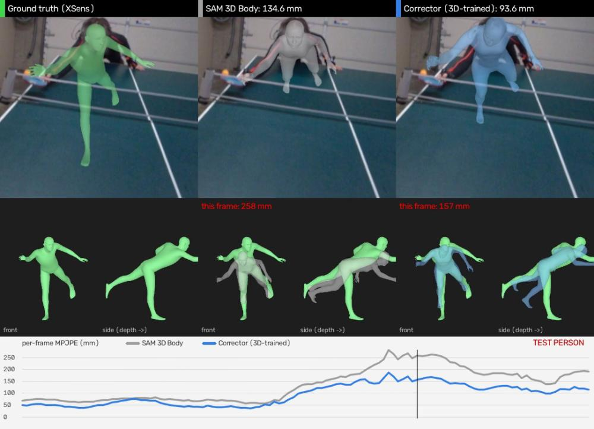

Figure 16. Table tennis, frame where the player leans over the table with one leg extended back (test person). Columns: ground truth (green), SAM 3D Body and the 3D-trained corrector; top, the body over the image; bottom, front and side views against the ground truth; the curve gives the error per frame.

In the figure above, SAM 3D Body folds the body forward and down (258 mm in this frame); the corrector brings the trunk near the ground truth (157 mm), and its trunk tilt error over the lean falls from 16.5° to 6.1°. The extended leg, however, is not recovered by any model: in the side view the ground truth has it raised behind the body and every model keeps it bent down. On this clip the 3D-trained corrector reaches 93.6 mm against an upper bound of 93.9 mm, so even the true 2D key points would not place that leg: it is hidden in depth, which a 2D prompt cannot express.

### 6.5 Training behaviour

The two figures below show the training curves of the final runs. They are short: the stage that runs the decoder in the loop costs about 83 min per epoch on our GPU, so stage 2 was trained for 2 epochs, and the logs keep one value per epoch. This is the weakest part of the study.

[figure not shown]

validationtraindotted: SAM 3D Body's own points

Figure 17. Stage 1 (2D objective): mean 2D error of the 12 key points per epoch. Training error keeps falling (7.1 → 4.2 px) while validation flattens at about 15 px from epoch 3, against 23.4 px for SAM 3D Body's own points.

In stage 1 the validation error stops improving after three epochs while the training error keeps falling, so the network fits the training people better than it generalises to new ones: more epochs would not help this stage, regularisation would.

[figure not shown]

3D-trainedbody context ±2 sbody context + forced occlusiondashed: train

Figure 18. Stage 2 (3D objective through the frozen decoder) and the body-context variants: MPJPE per epoch. "init" is the stage-1 model given to the decoder. Solid lines are validation, dashed lines training.

In stage 2 the validation error was still falling at the second epoch for the 3D-trained corrector (72.5 → 71.6 mm), so its schedule was cut before it converged. Forced occlusion makes training harder (training error about 5 mm above the variant without it) without changing validation. The validation pelvis error of the body-context variants moves little (193.7 → 191.4 and 189.4 mm) while their training pelvis error rises. One run per model was trained, with no seed variation.

## 7. Where the gain comes from

The corrector lowers the error from 84.2 to 67.6 mm. Two simpler corrections test what that gain needs. Both use the same people for training, validation and test, and the test set once.

**Fixed prompt offset.** No network. For each of the 12 key points, the mean of (true 2D point − SAM 3D Body's 2D point) over the 908 278 visible training frames, in units of the crop side (the mean was chosen over the median on validation, 17.7 against 17.8 px). At test time it is added to SAM 3D Body's points, which are then used as prompts exactly like the corrector's. It asks: *is the gain a constant difference between the two skeletons?*

**Image-free 3D correction.** A small network (per-frame MLP and a 2-layer Transformer, 1.7 M parameters) that reads SAM 3D Body's predicted body over ±16 frames (29 joints in 2D and 3D, and the pelvis in the camera) and adds a correction to the 18 joints of frame t. No image, no prompts, no decoder. It asks: *does the corrector read the image, or does it learn a bias of SAM 3D Body that the body alone reveals?*

[figure not shown]

SAM 3D BodyFixed prompt offsetImage-free 3D correctionPrompt corrector

Figure 19. MPJPE of the two baselines and the prompt corrector on four test subsets.

- **The fixed offset** shifts the prompts by a few pixels, mostly downward and largest at the hips and feet (dy +0.7 to +2.6 % of the crop). It lowers MPJPE by 3.6 mm (84.2 → 80.6), better on 189 of the first 223 clips and on every person, and gives almost nothing in PA-MPJPE (55.0 vs 55.1). Most of the gain needs a correction that changes from frame to frame. The same constant shift explains most of the pelvis gain of the 2D-trained stage (220.1 → 152.1 mm, against 136.8).
- **The image-free correction** reaches 68.7 mm over the 344 clips, 1.1 mm above the corrector; between people the difference is not distinguishable from zero (bootstrap interval over people [−6.2, +6.0] mm). It is better on the first 223 clips and on the occlusion clips, worse on the 121 new clips (71.1 vs 64.0), and better in PA-MPJPE (41.3 vs 47.5) and smoothness (10.6 vs 18.4 mm/frame²). A control with its own box, computed from SAM 3D Body's joints instead of the ground truth, loses 1.8 mm.

**What this means.** A large part of the corrector's gain is a systematic bias of SAM 3D Body on this data, which can be corrected from the predicted body alone. Whether the image and the prompts add something on top is not answered: no run combines both. The comparison is also not clean on one variable, since the image-free network reads 33 frames of the body and the corrector 3 frames of the image.

[figure not shown]

Figure 20. Training curves of the image-free correction: MPJPE on train (blue) and validation (orange) per epoch; the diamond is the single test value of the kept epoch. Almost all of the validation gain arrives in the first epoch (about 25 s); afterwards only the training error falls. With the pelvis term (right), the pelvis error falls to 39 mm on train and stays near 145 mm on validation: the placement of the body learned on training people does not transfer to new people.

## 8. From video to the robot

### 8.1 Retargeting to the Unitree G1

Retargeting turns a human motion into the joint angles of a robot with other proportions. We retargeted 35 test clips to a Unitree G1 humanoid (29 joints) with GMR, an open-source retargeting tool: the body of each model is first converted to SMPL-X (the body model GMR expects) in the world frame (the ground truth comes from NymeriaPlus' own SMPL fit), each predicted motion is filtered with SG before retargeting, and the heading of the first frame is aligned. The clips are the 30 with external occlusion and 6 chosen by the error of SAM 3D Body (one in both). The comparison is kinematic: it does not test whether the robot could execute the motion.

Figure 21. Robot motion against the ground-truth robot over 35 clips. Left: the corrector lowers the joint angle error by less than 1°. Right: its feet slide more than with SAM 3D Body.

The pose gain mostly does not survive retargeting: the joint angle error falls from 16.7 to 16.0°, joint jitter is the same (1.0 °/frame²), the base trajectory error is about 31–32 cm for both (mostly horizontal: the depth of the predicted pelvis), and the feet slide more. The corrector's pelvis moves more from frame to frame, and the retargeted feet follow it. In a few clips the change is large (below).

We checked the ground truth before using these metrics: the XSens capture drifts in height within some clips (the floor level under the lowest foot varies by a median of 10.4 cm over the 35 clips), but the base trajectory error is almost entirely horizontal (30.6 of 31.2 cm for SAM 3D Body) and does not change when the drift is removed.

[video not shown]

Figure 22. Standing up from a sofa. The clearest gain at the robot: joint angle error 26.8° with SAM 3D Body against 11.4° with the corrector (MPJPE 95.5 → 54.9 mm). Top: the real clip and each robot motion seen from the real camera; bottom: the same motions from the side. Columns: ground truth, ground truth with its height drift removed, SAM 3D Body + SG, prompt corrector + SG.

[video not shown]

Figure 23. A stretch. The corrector halves the pose error (112 → 61 mm), but its pelvis moves more between frames, and the robot's feet slide more (8.9 → 28.7 cm/s). Top: the real clip and each robot motion seen from the real camera; bottom: the same motions from the side. Columns: ground truth, ground truth with its height drift removed, SAM 3D Body + SG, prompt corrector + SG.

### 8.2 All 35 clips

Choose a clip to compare the four motions beside the real video (same layout as above). Every motion starts at the ground-truth pelvis of the first frame; the floor is at the ground-truth foot height of the first frame. In a few clips the ground-truth robot itself is wrong (for example the lunge, where it leans in the air): the retargeter fails on that input, so the robot metrics of those clips are not reliable.

[video not shown]

### 8.3 Imitation in physics simulation

A retargeted motion is only a reference. To see what a robot does with it, we trained controllers (*policies*: neural networks that output the robot's joint commands at every step) in the MuJoCo physics simulator, with reinforcement learning (the mjlab motion-tracking task, PPO, 4096 simulated robots in parallel), on one clip: a table-tennis reach where the player leans over the table. The scene includes a table-tennis table of regulation size, placed from the first frame of the video. Three policies, one per reference: SAM 3D Body + SG, prompt corrector + SG, and the ground truth with its height drift removed. Every policy is rewarded for following the reference's body positions, orientations and velocities and the horizontal position of the pelvis; an episode ends when the torso, a wrist or an ankle deviates from the reference by more than 25 cm in height.

First, the references themselves. The video below shows the three motions the policies are asked to imitate, before any physics: in the ground truth one foot always stays on the floor; in the motions estimated from video, both feet leave the floor at the same time, by up to 26 cm for SAM 3D Body and up to 9 cm for the corrector, without any jump in the real clip.

[video not shown]

Figure 24. The three reference motions on the table-tennis clip, before physics: the real clip, then each motion seen from the real camera (top) and from the side (bottom), with the training table. Every motion starts at the ground-truth pelvis of the first frame; the floor is at its real height.

Ground truthSAM 3D Body + SGPrompt corrector + SG

Figure 25. Height above the floor of the lower of the two ankles in each reference, over the clip. Above the dashed line (6 cm) both feet are off the floor: never in the ground truth, in 37 of 199 frames for SAM 3D Body and in 100 for the corrector, whose body floats a few centimetres all along.

SAM 3D Body + SGPrompt corrector + SGGround truth

SAM 3D Body + SGPrompt corrector + SGGround truth

Figure 26. Training of the three policies (Weights & Biases logs, mean over windows of 100 iterations). Left: mean episode length (an episode lasts at most 500 steps). Right: mean body position error against the reference. The runs stopped at iteration 18 000–18 500 of the 50 000 planned.

The ground-truth policy reaches full-length episodes within about 1000 iterations; the policies on SAM 3D Body and the corrector need longer, and the SAM 3D Body policy ends with the shortest episodes and the largest error (12 cm, against 7 cm for the corrector and 4 cm for the ground truth).

[video not shown]

Figure 27. The three trained policies (last checkpoint) on the table-tennis clip, with the real clip on the left; top from the real camera, bottom from the side. One environment, no noise, no pushes, starting at the first frame; no episode ends early.

[figure not shown]

reference motiontrained policy (final checkpoint)

Figure 28. Frames (of 199) in which both of the robot's ankles are more than 6 cm above the floor: the reference motions of the two models ask for it often, the trained policies almost never. One deterministic rollout per policy at its last checkpoint.

## 9. Failure cases and limitations

### 9.1 Failure cases seen in the renders

- **Another person in front.** In one walking clip, another person crosses between the camera and the participant for 1.5 s. SAM 3D Body (and so the corrector) reconstructs that person instead: the pelvis jumps from about 4.4 m to 1.3 m from the camera and back, and the robot would jump 3 m. The box of the participant contains both people. SAM 3D Body's paper shows that a mask prompt resolves exactly this case; we did not use it.
- **A distant person and a fast-turning camera.** When the person is 5–8 m away, the depth of the pelvis is off by 0.5–0.8 m, and with the camera turning quickly that error moves the body around the world by up to several metres between frames, for both models. The pose itself is stable; the filter, applied in the camera frame, does not remove these jumps.
- **Arms in depth.** In a stretching clip the arms project correctly (13–18 px in the image) but point the wrong way in 3D (26–31 cm at the wrists): a 2D prompt cannot fix depth.

### 9.2 Reliability of the ground truth

In strongly bent poses (picking something up from the floor, leaning over a table or a bed) the projected ground truth does not follow the body in the image in some frames (figure below). We checked the pairing of video and ground truth on one of these clips: the best time offset is 0 frames, the two fits that NymeriaPlus provides from the same suit (MHR and SMPL) agree within about 1 px in the image, and the stored 2D points are the exact projection of the 3D ones. Our extraction therefore reproduces the dataset's body as delivered; the difference comes from the inertial capture or its alignment, which we cannot inspect (the raw suit data are not in the package we use). How many frames are affected was not measured.

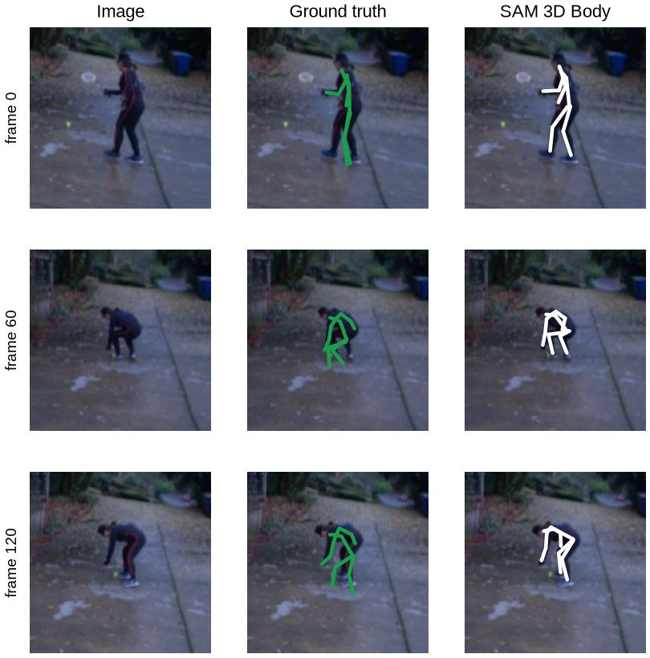

Figure 29. Three frames of a test clip where the participant bends to pick up a shuttlecock. Columns: the image, the ground-truth skeleton (green) and SAM 3D Body's skeleton (white). In the bent frames the ground-truth legs and head do not fall on the body in the image.

This matters for the reading of every result: part of the gain measured in bent poses may be the corrector moving towards the ground truth where the ground truth is less reliable, and part of the remaining error may not be error of the model.

### 9.3 Limitations

**Conditions of the study.** The box of the person comes from the ground truth and the camera intrinsics and pose are known. These were chosen to measure the model without detection errors and are part of the scope, so the absolute numbers are lower bounds.

- One training run per model, with no seed variation; differences of about 1 mm are not established, and bootstrap intervals were computed after the test.
- Short schedules for the stages that run the decoder (2 epochs); the 3D-trained corrector had not converged.
- Validation and test have 6 people each; table tennis has one person per split; the occlusion groups are small.
- The labels of 185 of the 204 sequences are automatic and were not checked by hand.
- The robot evaluation covers 35 clips chosen mostly for their occlusion; the physics evaluation covers one clip, one rollout per policy, and training stopped at about 37 % of the planned iterations.
- SAM 3D Body's number on its own benchmark was cited, not reproduced.

## 10. Conclusion and future work

Used frame by frame on daily-life video, SAM 3D Body makes two kinds of error: jitter, which a classical filter removes, and sustained errors of occluded or misplaced joints, which a filter cannot touch. Rewriting the prompts of its decoder with a small network, followed by the filter, lowers the pose error by 21 % on people it never saw and recovers 77 % of what the true key points would give. A network that never sees the image gets almost the same result, so most of this gain is a bias of the base model on this data rather than information read from the image. At the robot, the gain in pose barely survives retargeting, the feet slide more, and in simulation the policies trained on the two models end up alike, because physics forbids what both references get wrong.

Future work, in order of expected value: combine the image-free correction with the prompt corrector to test whether the image adds anything; a per-joint confidence the robot can use (we tested three signals that need no ground truth: how much the corrected body disagrees with SAM 3D Body's, how much two correctors disagree, and how unstable a joint is over time; they separate joints with more than 10 cm of error from the rest only weakly, and not at all for the feet); filter and correct the motion in the world frame rather than the camera frame; mask prompts when other people are near; more people in training; and reproducing SAM 3D Body on its own benchmark.

## Appendix A: ablations

Each ablation changes one thing, and its hypothesis was written before running it, except where noted. Numbers on 223 or 171 test clips come from before the test set was extended.

### A.1 Do the hand decoders improve the body?

**Question**

SAM 3D Body can run extra decoders for the hands. Do they improve the wrists?

**Hypothesis**

The hand decoders lower the wrist error.

**How**

Body mode against full mode on the first dance clip (1801 frames).

**Result**

MPJPE 84.0 against 84.1 mm, left wrist 211.7 in both, 144 against 450 ms per frame. Rejected.

**Why**

The hand decoders refine the fingers and the hand rotation; the wrist position comes from the arm chain, and the hands are only a few pixels wide in these images. Body mode is the baseline.

The classical filters ablation is in Section 4.4.

### A.2 Train in 2D or in 3D through the frozen decoder?

**Question**

Is it better to train the corrector to reach the true 2D points, or to produce the best 3D body?

**Hypothesis**

The 3D error improves with the 3D objective, because it optimises the 3D error itself.

**How**

Same network, same data; stage 1 only against stage 1 + stage 2, on the 223 test clips.

**Result**

MPJPE: SAM 3D Body 90.6, 2D objective 79.3, 3D objective 71.9 mm. Held. But the pelvis error of the 3D objective is worse (198.6 → 136.3 mm with 2D, 193.3 with 3D), and the 2D error of its points moves back towards the level of SAM 3D Body's own points.

**Why**

[figure not shown]

Figure 30. The two objectives on the 223 test clips: the 3D objective gives the lower pose error, the 2D objective the lower position error.

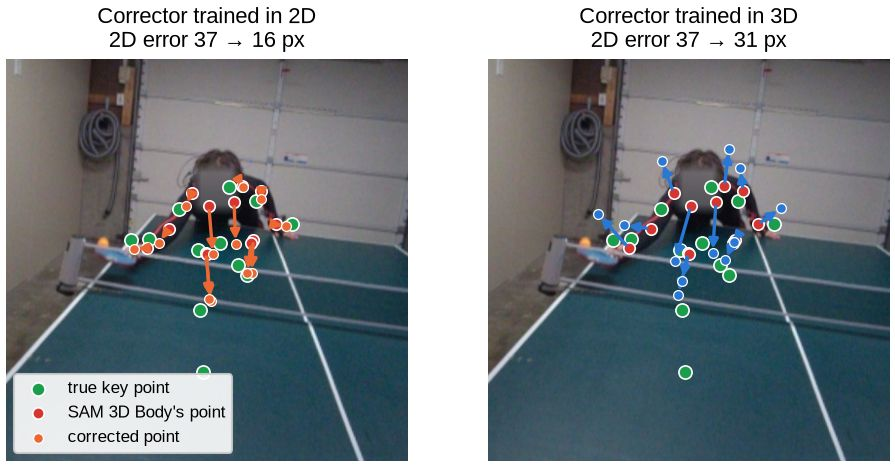

Figure 31. What each objective does to the 12 points on one test frame. Red: SAM 3D Body's points; green: the true key points; arrows: the corrections. Trained in 2D, the corrector moves the points onto the true ones (37 → 16 px). Trained in 3D, it moves them elsewhere (37 → 31 px), to the positions that make the decoder produce the best 3D pose: the prompts stop being the joints and become a control signal.

### A.3 Adding the body position to the loss and the body as context

**Question**

Can the 3D objective keep the body in place, and does the motion around the frame help?

**Hypothesis**

The pelvis error improves, the MPJPE goes down, and a ±16-frame window of the predicted body reduces the jitter.

**How**

Three changes run together (a decision of the team, accepting that their effects cannot be separated): a reprojection term in the loss, SAM 3D Body's predicted body as input, over ±16 frames.

**Result**

On the 223 test clips: pelvis 193.3 → 146.5 mm (held); MPJPE 71.9 → 72.6 mm (not held); acceleration error 18.9 → 19.2 mm/f² (not held).

**Why**

The reprojection term keeps the body where it is in the image at a small cost in pose. The window does not bring smoothness: each frame is still corrected on its own.

### A.4 Filtering after the corrector

**Question**

Does the filter that removes SAM 3D Body's jitter also remove the jitter the corrector adds, without losing its gain?

**Hypothesis**

The acceleration error of every corrector falls at least 70 % and ends below the unfiltered baseline; MPJPE changes by less than 2 %; the best corrector keeps at least a 15 % reduction against the filtered baseline; the pelvis error changes by less than 5 %.

**How**

Savitzky-Golay (window 9, order 2) on the 3D joints of every model, 171 test clips.

**Result**

Held on the four points: acceleration error 20.0 → 4.0 (−80 %), MPJPE −1.4 %, 70.4 against 88.3 mm for the filtered baseline (−20.3 %), pelvis −1 %.

**Why**

The jitter is high-frequency and the corrections are low-frequency, so the filter separates them. The filter does not repair the pelvis bias of the 3D objective.

### A.5 More frames of the same people

**Question**

Does more data of the same people help?

**Hypothesis**

The MPJPE falls by less than 2 mm.

**How**

Training clips from 685 to 1038 (+58 % frames), same people and categories, same recipe, evaluated on 171 test clips.

**Result**

71.4 → 70.1 mm (−1.3; 95 % interval over clips [−1.6, −0.8], computed after the test); better on 5 of 6 people. Held.

**Why**

More frames of the same people repeat what the network already saw; the gain is small but consistent.

### A.6 More people

**Question**

Does adding new people help more than adding frames?

**Hypothesis**

The MPJPE falls by less than 2 mm on the same test clips; on the new test clips the gain over SAM 3D Body is at least 15 %.

**How**

2906 more training and validation clips, of which the training ones add 50 new people and +10 % samples; same recipe, same 223 test clips.

**Result**

71.9 → 70.3 mm (−1.6; 95 % interval over clips [−1.9, −1.3], over people [−2.2, −1.1], computed after the test); better on 174 of 223 clips and on 6 of 6 people. On the 121 new test clips −15.5 % against SAM 3D Body. Held.

**Why**

With +10 % samples the new people give more than +58 % frames of the same people did: variety of people matters more than quantity. On the new test clips the gain over the previous model cannot be told from zero, so the benefit is on the people already represented.

### A.7 A longer context window, with masking

**Question**

Can a window of ±2 s of the predicted body recover a limb that stays hidden for longer than ±0.5 s?

**Hypothesis**

The pelvis error of the body-context variant improves over the ±16-frame version; the trunk tilt error on the table-tennis clip does not get worse.

**How**

Window ±60 frames, frames outside the clip masked in the attention (52 % of the training frames have a window that crosses a clip end). It was trained together with the additional people of A.6, so the window and the data change at once.

**Result**

Pelvis 146.5 → 145.3 mm (held, barely); MPJPE 72.6 → 71.1; trunk tilt error on the lean 5.8° → 6.4° (not held). On the occlusion clips it is worse than the 3D-trained corrector (74.9 against 71.8 mm).

**Why**

The window only adds the predicted body, not the image of the other frames; if SAM 3D Body is wrong about a limb during the whole occlusion, the window repeats that error. Its cost in memory is small (from 33 to 121 tokens next to 3072 latent tokens).

### A.8 Forced occlusion during training

**Question**

Does hiding body parts during training teach the corrector to infer them?

**Hypothesis**

On the 15 "table over the legs" clips the forced occlusion lowers MPJPE by at least 2 mm, and by at least 1 mm on the 30 occlusion clips; on the 223 clips the two variants stay within 1 mm.

**How**

With probability 0.5 per sample, the latent tokens inside the true 2D box of the lower body, one leg or one arm (plus 15 % margin) are replaced by one learned token in t−1, t and t+1, and the joints of that part get noise (5 % of the crop in 2D, 5 cm in 3D) in the body window and in the input points. Everything else equal to A.7.

**Result**

−0.8 mm on the 15 clips (interval [−1.7, −0.2]), +0.1 mm on the 30, +0.6 mm on the 223. Not held. The acceleration error fell by about 1 mm/f², which was not predicted.

**Why**

Masking the latent removes evidence but keeps SAM 3D Body's first pass, which was computed from the clean image, so the occlusion is not the one the model meets at test time. Discarded.

### A.9 How the latent is stored

**Question**

How much can the stored latent be compressed without changing what the decoder produces?

**Hypothesis**

A storage format is acceptable if the decoder's pose moves less than 1 mm.

**How**

The first-pass decoder on the stored latent against the full latent, every fourth frame of two test people.

**Result**

PCA to 256 / 384 / 512 / 768 channels: 12.0 / 5.8 / 3.4 / 1.7 mm. 8-bit float: 0.27–0.55 mm. 8-bit integer per channel: 0.10 mm (1.31 MB per frame). 6 / 5 / 4 bits: 0.52 / 1.08 / 2.36 mm.

**Why**

The channels of the latent have very different ranges, so one scale per channel keeps them; reducing the number of channels discards information the decoder uses. 8-bit integers were kept.

[figure not shown]

### A.10 A pretrained motion prior

**Question**

Can a generative model of human motion fill a limb that is hidden, from the motion of the rest of the body?

**Expected**

If the prior recovers the leg of the table-tennis clip when we tell it which joints are hidden, the idea is worth training on our data; if it does not even reproduce the visible motion, this prior cannot be used. (Written before the run, not before the idea.)

**How**

The released MDM trained on HumanML3D, frozen, with DNO: its input noise is optimised so that the generated motion matches an observation. Three costs on the table-tennis clip, all starting from the motion of SAM 3D Body: (control) all 22 joints of SAM 3D Body in 3D; (1) only the trusted joints in 3D, with the hidden ones taken from the ground-truth occlusion mask and the legs behind the table marked by hand (an upper bound); (2) no ground truth: the 12 corrected 2D points, each weighted by 1/b, projected with the known camera, so that depth is left to the prior. In MDM's skeleton at 20 fps, so the numbers are not comparable with the rest of the report. We also asked MDM to reproduce the real motion itself.

**Result**

SAM 3D Body 111.1 mm (legs 195.4). Control 162.3, (1) 173.2, (2) 184.9 mm; legs 251–297 mm. Reproducing the real motion: 142.2 mm after 300 optimisation steps and 72.7 mm after 1000.

**Why**

[figure not shown]

Figure 33. The pretrained motion prior on the table-tennis clip (MPJPE in MDM's 22-joint skeleton, 20 fps). Every use of the prior is worse than SAM 3D Body alone, including the one that is told which joints are hidden.

### A.11 The body-context variant on the full test set

**Question**

Does giving the corrector SAM 3D Body's predicted body over ±2 s (one token per frame, frames outside the clip masked) improve the pose, the position of the body, or what reaches the robot?

**How**

Same training recipe as the prompt corrector (2 epochs in 3D from the 2D-trained stage), with the 2D reprojection term in the loss; also a version with forced occlusion (A.8). Evaluated once on the 344 test clips, on the 30 occlusion clips and, after SG, on the 35 retargeted clips.

**Result**

Pose: 67.8 mm against 67.6 (with SG 66.9 against 66.7). Position: pelvis error 149.5 mm against 176.8 (−15 %). Occlusion clips: 74.9 against 71.8 mm, pelvis 252.1 against 365.8 mm. Robot: joint angle error 15.6° against 16.0°, base trajectory 28.6 against 32.4 cm, foot sliding 57.6 against 68.0 cm/s.

**Why**

The window carries SAM 3D Body's predicted bodies, not the images of the other frames, so it cannot recover a limb SAM 3D Body gets wrong for the whole window; the reprojection term keeps the body where it is in the image, which is what improves the pelvis and, through it, the base trajectory and the feet of the robot.

Figure 34. The body-context variant against the prompt corrector on the 344 test clips: the same pose error (left), a better placed body (right).

## Appendix B: reproducing the results

The code is in the repository; the decision record (*RESEARCH_DECISION_BOOK.md*) gives every decision, hypothesis and result in order. The list of clips (sequence, start and end time, label) is in the repository; the extracted clips are in the team's dataset on Hugging Face; the raw recordings come from Nymeria under its own licence.

Table 5. The models of this report and their run names in the repository.

| model in this report | run |
| --- | --- |
| Prompt corrector, 2D-trained | 2d_e16 |
| Prompt corrector (final) | 3d_e16 |
| Prompt corrector with body context (±2 s) | v2w_e16 |
| … + forced occlusion | v2wo_e16 |
| Fixed prompt offset | offset (E17) |
| Image-free 3D correction / + pelvis / own box | b3d_e18 / b3dp_e18 / b3dn_e18 |
| Physics policies | stride_robot: sam3db_table, corrector_table, gt_table |

## Appendix C: use of AI assistants

We used AI assistants (Claude Code and ChatGPT) as coding agents and for analysis: they wrote most of the code, ran the extraction, training and evaluation, and helped word the reports. The decisions, the hypotheses written before each experiment and the interpretation of the results are the team's; the decision record says, entry by entry, where an assistant was used.

## References

1. A. Savitzky and M. J. E. Golay. Smoothing and differentiation of data by simplified least squares procedures. *Analytical Chemistry*, 1964.
2. G. Casiez, N. Roussel and D. Vogel. 1€ filter: a simple speed-based low-pass filter for noisy input in interactive systems. *CHI*, 2012.
3. A. Zeng et al. SmoothNet: a plug-and-play network for refining human poses in videos. *ECCV*, 2022.
4. G. Tevet, S. Raab, B. Gordon, Y. Shafir, D. Cohen-Or and A. H. Bermano. Human Motion Diffusion Model. *ICLR*, 2023. arXiv:2209.14916.
5. C. Guo et al. Generating diverse and natural 3D human motions from text. *CVPR*, 2022.
6. N. Mahmood, N. Ghorbani, N. F. Troje, G. Pons-Moll and M. J. Black. AMASS: Archive of motion capture as surface shapes. *ICCV*, 2019.
7. K. Karunratanakul et al. Optimizing diffusion noise can serve as universal motion priors. *CVPR*, 2024.
8. L. Ma et al. Nymeria: a massive collection of multimodal egocentric daily motion in the wild. *ECCV*, 2024. arXiv:2406.09905. Project page and figures: projectaria.com/datasets/nymeria. NymeriaPlus: Meta, released data.
9. X. Yang et al. SAM 3D Body: Robust full-body human mesh recovery. arXiv:2602.15989, 2026.
10. H. Joo et al. Panoptic Studio: A massively multiview system for social motion capture. *ICCV*, 2015.
11. H. Joo et al. Panoptic Studio: A massively multiview system for social interaction capture. *IEEE TPAMI*, 2017. arXiv:1612.03153. Dataset: domedb.perception.cs.cmu.edu.
12. A. Ferguson et al. MHR: Momentum Human Rig. arXiv:2511.15586, 2025.